# Analyse descriptive du jeu de données des vins

# I - Cas du vin rouge

```python
###cas de vin rouge
import os
import pandas as pd
import matplotlib.pyplot as plt
import seaborn as sns
import numpy as np
import sklearn.decomposition as pca
import sklearn.preprocessing as standardscaler

##### Importation des donnees######
# os.chdir("C:/Users/hp/Documents/python avancee")
data1 = pd.read_csv("winequality-red.csv",sep =";")
```

## valeurs manquante

```python
#analysons les donnees manquantes

data1.isnull().sum()
print("")
```

```python
# Définir les limites des intervalles et les noms des catégories
bins = [0, 2, 4, 5, 6, 7, 8, 9, 10]
labels = ['mauvais', 'Médiocre', 'Ordinaire', 'Correct', 'assez bon', 'Bon', 'Très Bon', 'Excellent']

# Utiliser pd.cut() pour remplacer la colonne 'quality' existante
data1['quality'] = pd.cut(data1['quality'], bins=bins, labels=labels, right=False)

# Afficher les premières lignes du DataFrame avec les nouvelles notations
print(data1["quality"].head())
```

```
0      Correct
1      Correct
2      Correct
3    assez bon
4      Correct
Name: quality, dtype: category
Categories (8, object): ['mauvais' < 'Médiocre' < 'Ordinaire' < 'Correct' < 'assez bon' < 'Bon' < 'Très Bon' < 'Excellent']
```

```python
# Transformer le type de la variable quality
data1['quality'] = data1['quality'].astype(object)
print()
```

## 2-Analyse descriptives univariees de la table de donnees

```python
#analyse descriptive du jeu de donnees(les variables quantitatives)
```

```python
data1.describe()
print()
```

```python
#description de la variable qualitative
data1.describe(include = 'object')
```

|  | quality |
| --- | --- |
| count | 1599 |
| unique | 6 |
| top | Correct |
| freq | 681 |

Observons le resultat description de la variable d'interet qui nous donne comme information : dans 1599 individus ,les indivus 'correct' presentent en frequence maximale 681

#### Boites à moustache des variables quantitatives

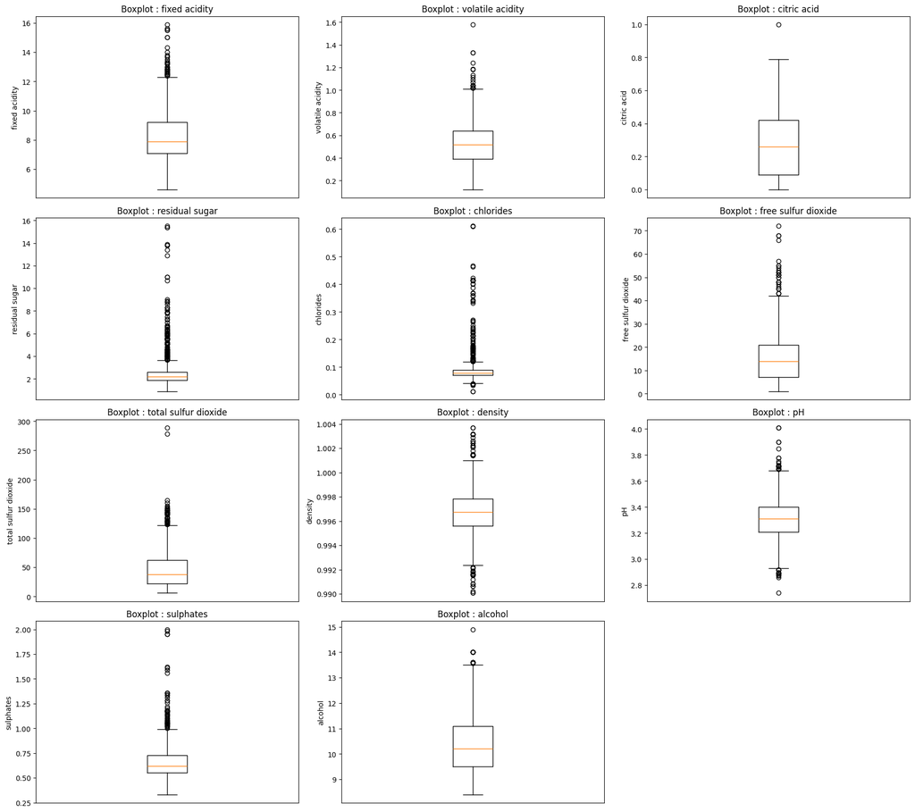

```python
#analyse descriptive des variables quatitatives
# data_numeric = data1.select_dtypes(include=['number'])
# for column in data_numeric.columns:
#     plt.figure(figsize=(6, 4))
#     plt.boxplot(data_numeric[column])
#     plt.title(f'Boxplot : {column}')
#     plt.xticks([])
#     plt.ylabel(column)
#     plt.show()

# Assume data1 is your DataFrame

data_numeric = data1.select_dtypes(include=['number'])

num_cols = len(data_numeric.columns)

# Determine a suitable number of rows and columns for the subplots
num_rows = (num_cols + 2) // 3  # Ensure enough rows for all columns
num_cols_per_row = min(3, num_cols)  # Limit to 3 columns per row for better readability


fig, axes = plt.subplots(num_rows, num_cols_per_row, figsize=(6 * num_cols_per_row, 4 * num_rows)) # Adjust figure size for better visualization


# Flatten the axes array if it's a 2D array, making it easier to iterate
if num_rows > 1 or num_cols_per_row > 1:
    axes = axes.flatten()
else:
    axes = [axes]  # Ensure it's iterable even if it's a single subplot

for i, column in enumerate(data_numeric.columns):
    ax = axes[i]
    ax.boxplot(data_numeric[column])
    ax.set_title(f'Boxplot : {column}')
    ax.set_xticks([])  # Hide x-axis ticks
    ax.set_ylabel(column)

# Remove any unused subplots if the number of columns is not a multiple of the subplots per row
for i in range(len(data_numeric.columns), len(axes)):
    fig.delaxes(axes[i])

plt.tight_layout()  # Adjust subplot parameters for a tight layout
plt.show()
```

Ici nous constons d'apres notre boxplot que chaque variable presente des valeurs aberante que nous allons utiliser la methode utiliser la methode de winsoristion qui est la methode qui ramene les valeurs aberrantes positive au maximuim et valeurs aberantes negatives au minimuim pour eviter de perdre au maximuim les informations.Cette methode est la suivante

```python
import numpy as np

for i in range(data1.shape[1] - 1):
    col = data1.columns[i]
    Q1 = data1[col].quantile(0.25)
    Q3 = data1[col].quantile(0.75)
    IQR = Q3 - Q1
    limite_basse = Q1 - 1.5 * IQR
    limite_haute = Q3 + 1.5 * IQR

    # Méthode de Winsorisation (capping)
    #remplacement des valeurs aberrantes qui sont inferieurs au min par le min
     #remplacement des valeurs aberrantes qui sont superieurs au max par le max
    data1[col] = data1[col].clip(lower=limite_basse, upper=limite_haute)
```

#### Traitement des valeurs abérrantes

Pour traiter les valeur abérrantes, nous utliserons la méthode de winsorisation.

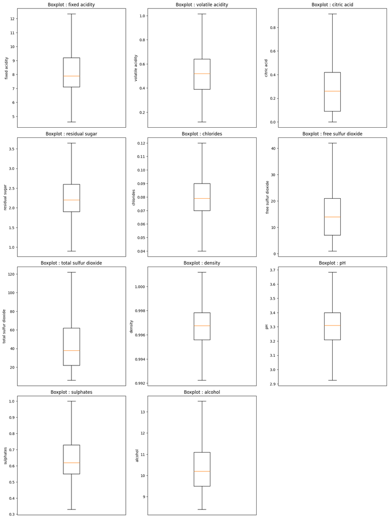

```python
#analyse descriptive des variables quatitatives
# data_numeric0 = data1.select_dtypes(include=['number'])
# for column in data_numeric0.columns:
#     plt.figure(figsize=(6, 4))
#     plt.boxplot(data_numeric0[column])
#     plt.title(f'Boxplot : {column}')
#     plt.xticks([])
#     plt.ylabel(column)
#     plt.show()
 # Assurez-vous que pandas est installé (pip install pandas)

# Supposons que data1 est un DataFrame pandas
# Pour l'exemple, créons un DataFrame factice :


data_numeric0 = data1.select_dtypes(include=['number'])

num_cols = len(data_numeric0.columns)

# Déterminer le nombre de lignes et de colonnes pour la grille de sous-graphiques
import math
num_cols_per_row = 3 # Modifier cette valeur pour ajuster la disposition
num_rows = math.ceil(num_cols / num_cols_per_row)


fig, axes = plt.subplots(num_rows, num_cols_per_row, figsize=(15, 5 * num_rows)) # Ajuster la taille de la figure

# Aplatir le tableau d'axes pour faciliter l'itération
axes = axes.flatten()

for i, column in enumerate(data_numeric0.columns):
    ax = axes[i]
    ax.boxplot(data_numeric0[column])
    ax.set_title(f'Boxplot : {column}')
    ax.set_xticks([])  # Enlever les ticks sur l'axe x
    ax.set_ylabel(column)


# Supprimer les axes inutilisés (si le nombre de colonnes n'est pas un multiple de num_cols_per_row)
for i in range(num_cols, len(axes)):
    fig.delaxes(axes[i])

plt.tight_layout()  # Ajuster la disposition pour éviter les chevauchements
plt.show()
```

#### Analyse de la normalité de chaque variable.

```
La variable fixed acidity ne suit pas une loi normale (p-value=2.862e-24)
La variable volatile acidity ne suit pas une loi normale (p-value=2.792e-10)
La variable citric acid ne suit pas une loi normale (p-value=4.911e-39)
La variable residual sugar ne suit pas une loi normale (p-value=1.711e-33)
La variable chlorides ne suit pas une loi normale (p-value=9.519e-11)
La variable free sulfur dioxide ne suit pas une loi normale (p-value=1.438e-33)
La variable total sulfur dioxide ne suit pas une loi normale (p-value=1.140e-40)
La variable density suit une loi normale (p-value=7.058e-01)
La variable pH suit une loi normale (p-value=6.763e-01)
La variable sulphates ne suit pas une loi normale (p-value=2.607e-29)
La variable alcohol ne suit pas une loi normale (p-value=6.378e-30)
```

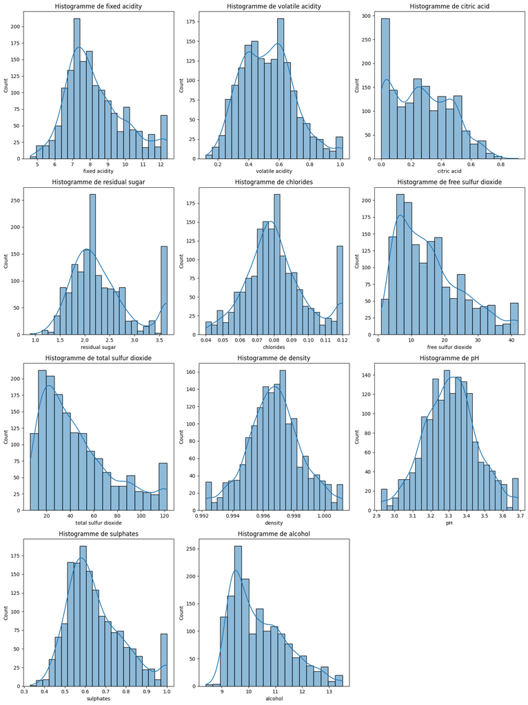

```python
#Analysons la normalité de chaque variable
# Analyse de la normalité
import scipy.stats as stats

# # Création d'un histogramme et d'un test de normalité pour chaque variable
import matplotlib.pyplot as plt
import seaborn as sns
from scipy import stats

# Supposons que data_numeric0 soit votre DataFrame numérique

num_cols = len(data_numeric0.columns)
# Déterminer le nombre de lignes et de colonnes pour la grille de sous-plots
# Vous pouvez ajuster ces valeurs en fonction du nombre de variables et de la taille souhaitée
num_rows = (num_cols + 2) // 3  # Essaie d'avoir environ 3 colonnes
num_cols_grid = min(num_cols, 3) # Maximum de 3 colonnes par défaut

fig, axes = plt.subplots(nrows=num_rows, ncols=num_cols_grid, figsize=(15, 5 * num_rows))
axes = axes.flatten() # Aplatir le tableau d'axes pour faciliter l'itération

for i, column in enumerate(data_numeric0.columns):
    sns.histplot(data_numeric0, x=column, kde=True, ax=axes[i])
    axes[i].set_title(f"Histogramme de {column}")

    statistic, p_value = stats.normaltest(data_numeric0[column])
    if p_value < 0.05:
        print(f"La variable {column} ne suit pas une loi normale (p-value={p_value:.3e})")
    else:
        print(f"La variable {column} suit une loi normale (p-value={p_value:.3e})")

# Supprimer les sous-plots vides s'il y a moins de variables que d'emplacements dans la grille
if num_cols < len(axes):
    for j in range(num_cols, len(axes)):
        fig.delaxes(axes[j])

plt.tight_layout() # Ajuste l'espacement entre les sous-plots
plt.show()
```

#### Histogramme de la variable "qualité"

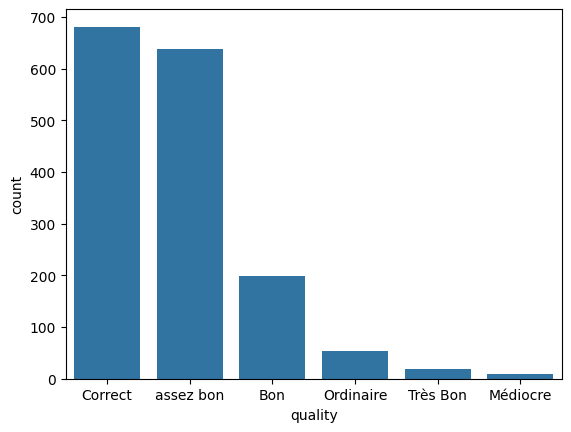

```python
# Analyse de la variable qualitative

sns.countplot(x=data1['quality'])
```

# II - cas du vin blanc

```python
import os
import pandas as pd
import matplotlib.pyplot as plt
import seaborn as sns
import numpy as np
import sklearn.decomposition as pca
import sklearn.preprocessing as standardscaler

##### Importation des donnees######
data2 = pd.read_csv("winequality-white.csv",sep =";")
```

#### Transformation de la variable "qualité"

Nous associerons chaque valeur numérique à une valeur qualitative

```python
# Définir les limites des intervalles et les noms des catégories
bins = [0, 2, 4, 5, 6, 7, 8, 9, 10]
labels = ['mauvais', 'Médiocre', 'Ordinaire', 'Correct', 'assez bon', 'Bon', 'Très Bon', 'Excellent']

# Utiliser pd.cut() pour remplacer la colonne 'quality' existante
data2['quality'] = pd.cut(data2['quality'], bins=bins, labels=labels, right=False)

# Afficher les premières lignes du DataFrame avec les nouvelles notation
```

```python
# Transformer le type de la variable quality
data2['quality'] = data2['quality'].astype(object)
```

## 2-Analyse descriptive univariée

### analyse descriptive du jeu de donnees(les variables quantitatives)

#### boites à moustaches

[figure not shown]

```python
#analyse descriptive des variables quatitatives
import matplotlib.pyplot as plt

# Supposons que data_numeric soit votre DataFrame numérique

num_cols = len(data_numeric.columns)
# Déterminer le nombre de lignes et de colonnes pour la grille de sous-plots
num_rows = (num_cols + 2) // 3  # Essaie d'avoir environ 3 colonnes
num_cols_grid = min(num_cols, 3) # Maximum de 3 colonnes par défaut

fig, axes = plt.subplots(nrows=num_rows, ncols=num_cols_grid, figsize=(15, 5 * num_rows))
axes = axes.flatten() # Aplatir le tableau d'axes pour faciliter l'itération

for i, column in enumerate(data_numeric.columns):
    axes[i].boxplot(data_numeric[column])
    axes[i].set_title(f'Boxplot : {column}')
    axes[i].set_xticks([]) # Supprimer les ticks de l'axe x (inutiles pour les boxplots individuels)
    axes[i].set_ylabel(column)

# Supprimer les sous-plots vides s'il y a moins de variables que d'emplacements dans la grille
if num_cols < len(axes):
    for j in range(num_cols, len(axes)):
        fig.delaxes(axes[j])

plt.tight_layout() # Ajuste l'espacement entre les sous-plots
plt.show()
```

```python
import numpy as np

for i in range(data2.shape[1] - 1):
    col = data2.columns[i]
    Q1 = data2[col].quantile(0.25)
    Q3 = data2[col].quantile(0.75)
    IQR = Q3 - Q1
    limite_basse = Q1 - 1.5 * IQR
    limite_haute = Q3 + 1.5 * IQR

    # Méthode de Winsorisation (capping)
    #remplacement des valeurs aberrantes qui sont inferieurs au min par le min
     #remplacement des valeurs aberrantes qui sont superieurs au max par le max
    data2[col] = data2[col].clip(lower=limite_basse, upper=limite_haute)
```

#### Boites à moustaches sans valeurs abérrantes

le traitement des valeurs abérrantes s'est fait par Winsorisation.

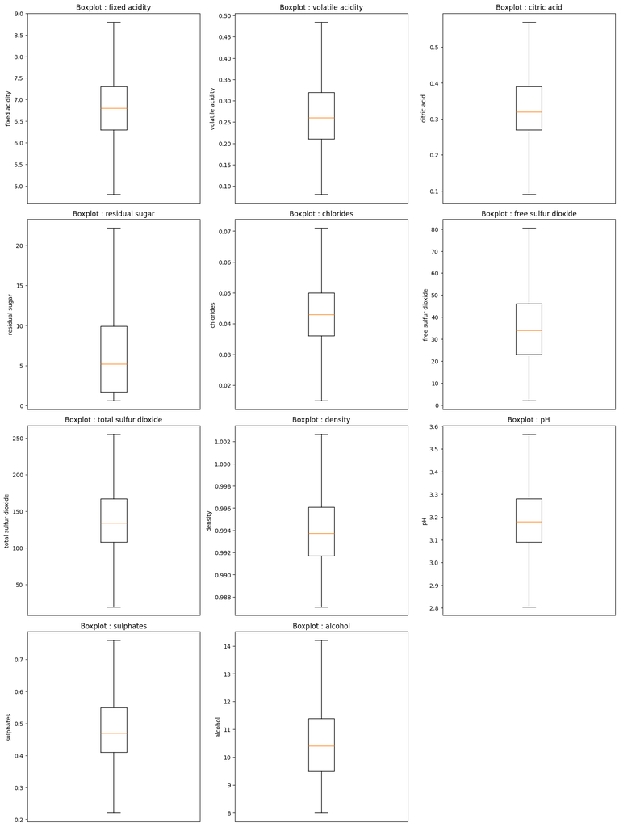

```python
#analyse descriptive des variables quatitatives
data_numeric = data2.select_dtypes(include=['number'])
import matplotlib.pyplot as plt

# Supposons que data_numeric soit votre DataFrame numérique

num_cols = len(data_numeric.columns)
# Déterminer le nombre de lignes et de colonnes pour la grille de sous-plots
num_rows = (num_cols + 2) // 3  # Essaie d'avoir environ 3 colonnes
num_cols_grid = min(num_cols, 3) # Maximum de 3 colonnes par défaut

fig, axes = plt.subplots(nrows=num_rows, ncols=num_cols_grid, figsize=(15, 5 * num_rows))
axes = axes.flatten() # Aplatir le tableau d'axes pour faciliter l'itération

for i, column in enumerate(data_numeric.columns):
    axes[i].boxplot(data_numeric[column])
    axes[i].set_title(f'Boxplot : {column}')
    axes[i].set_xticks([]) # Supprimer les ticks de l'axe x (inutiles pour les boxplots individuels)
    axes[i].set_ylabel(column)

# Supprimer les sous-plots vides s'il y a moins de variables que d'emplacements dans la grille
if num_cols < len(axes):
    for j in range(num_cols, len(axes)):
        fig.delaxes(axes[j])

plt.tight_layout() # Ajuste l'espacement entre les sous-plots
plt.show()
```

#### Analyse de la normalité de chaque variable.

```
La variable fixed acidity ne suit pas une loi normale (p-value=4.560e-13)
La variable volatile acidity ne suit pas une loi normale (p-value=2.915e-58)
La variable citric acid ne suit pas une loi normale (p-value=2.393e-25)
La variable residual sugar ne suit pas une loi normale (p-value=2.195e-96)
La variable chlorides ne suit pas une loi normale (p-value=7.417e-30)
La variable free sulfur dioxide ne suit pas une loi normale (p-value=1.761e-33)
La variable total sulfur dioxide ne suit pas une loi normale (p-value=1.842e-15)
La variable density ne suit pas une loi normale (p-value=1.441e-73)
La variable pH ne suit pas une loi normale (p-value=1.134e-15)
La variable sulphates ne suit pas une loi normale (p-value=7.893e-57)
La variable alcohol ne suit pas une loi normale (p-value=3.609e-94)
```

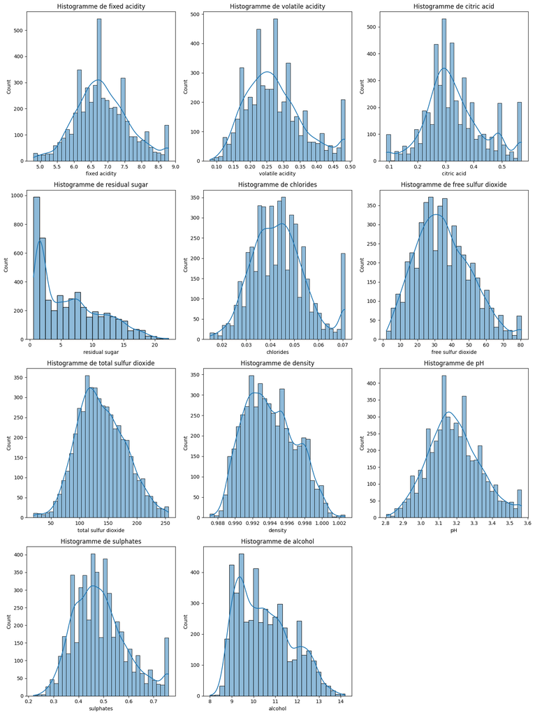

```python
#Analysons la normalité de chaque variable
# Analyse de la normalité
import matplotlib.pyplot as plt
import seaborn as sns
import scipy.stats as stats

# Supposons que data_numeric1 soit votre DataFrame numérique
data_numeric1 = data_numeric
num_cols = len(data_numeric1.columns)
# Déterminer le nombre de lignes et de colonnes pour la grille de sous-plots
num_rows = (num_cols + 2) // 3  # Essaie d'avoir environ 3 colonnes
num_cols_grid = min(num_cols, 3) # Maximum de 3 colonnes par défaut

fig, axes = plt.subplots(nrows=num_rows, ncols=num_cols_grid, figsize=(15, 5 * num_rows))
axes = axes.flatten() # Aplatir le tableau d'axes pour faciliter l'itération

for i, column in enumerate(data_numeric1.columns):
    sns.histplot(data_numeric1, x=column, kde=True, ax=axes[i])
    axes[i].set_title(f"Histogramme de {column}")

    statistic, p_value = stats.normaltest(data_numeric1[column])
    if p_value < 0.05:
        print(f"La variable {column} ne suit pas une loi normale (p-value={p_value:.3e})")
    else:
        print(f"La variable {column} suit une loi normale (p-value={p_value:.3e})")

# Supprimer les sous-plots vides s'il y a moins de variables que d'emplacements dans la grille
if num_cols < len(axes):
    for j in range(num_cols, len(axes)):
        fig.delaxes(axes[j])

plt.tight_layout() # Ajuste l'espacement entre les sous-plots
plt.show()
```

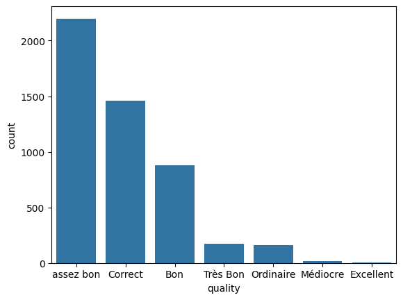

```python
# Analyse de la variable qualitative

sns.countplot(x=data2['quality'])
```

# 3 - Analyse bivariees

```python
# 1- cas vin rouge
```

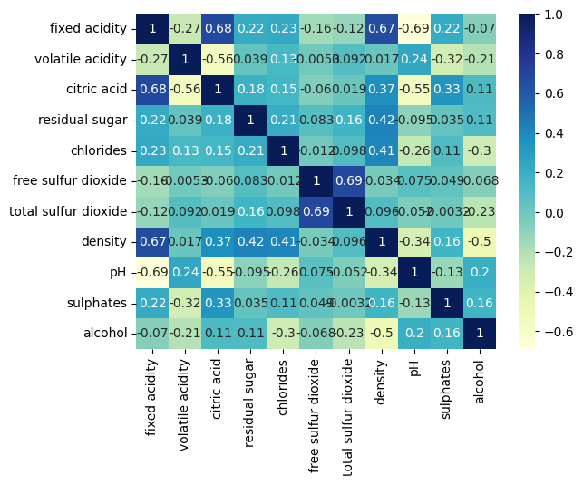

```python
# Identifier les colonnes numériques
numeric_cols = data_numeric0.select_dtypes(include=['number']).columns

# Calculer la matrice de corrélation uniquement pour les colonnes numériques
corr_matrix_numeric = data_numeric0[numeric_cols].corr()

# Afficher la heatmap
sns.heatmap(corr_matrix_numeric, annot=True, cmap="YlGnBu")
plt.show()
```

Nous observons les correlations entre : fixed acidity et density , fixed acidity et citric acid ,total sulfur dioxide et free sulfur dioxide

```python
# Supprimer des variales
data_numeric0['citric acid']
data_numeric0['free sulfur dioxide']
data_numeric0['density']
print("")
```

```python
import pandas as pd
import pandas as pd
from scipy import stats



# Déterminer le nombre de colonnes pour la mise en page des sous-plots
num_cols = len(data_numeric0.columns)
# Confirmation des liaison avec un test de Kruskal-Wallis pour chaque variable

print("Variable \t\t impact sur qualité \t p-value")
for column in data_numeric0.columns:
    _, p_value = stats.kruskal(*[data_numeric0[column][data1.quality== quality] for quality in data1.quality.unique()])
    if p_value < 0.05:
        print(f"{column} \t\t oui \t {p_value}")
    else:
        # print(f"La variable {column} n'a pas  d'un impact sur la qualité du vin rouge (p-value={p_value})")
        print(f"{column} \t\t non \t {p_value}")
```

```
Variable 		 impact sur qualité 	 p-value
fixed acidity 		 oui 	 1.1870191270804252e-05
volatile acidity 		 oui 	 2.254726127976826e-50
citric acid 		 oui 	 1.1374798403918537e-18
residual sugar 		 non 	 0.2462668705673935
chlorides 		 oui 	 3.166435910719008e-14
free sulfur dioxide 		 oui 	 8.93846472386413e-06
total sulfur dioxide 		 oui 	 2.022351878477807e-22
density 		 oui 	 9.73153839075505e-13
pH 		 oui 	 0.0002454929559365054
sulphates 		 oui 	 2.5208330334573602e-48
alcohol 		 oui 	 6.258208134913375e-87
```

notre test permet de dire que La variable residual sugar n'a pas d'un impact sur la qualité du vin rouge mais nous allons travailler cette variable d'apres sa definition concernant le vin

## II-cas vin blanc

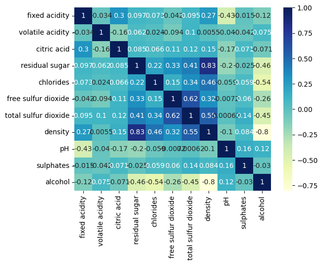

```python
# Identifier les colonnes numériques
numeric_col1 = data_numeric1.select_dtypes(include=['number']).columns

# Calculer la matrice de corrélation uniquement pour les colonnes numériques
corr_matrix_numeric1 = data_numeric1[numeric_col1].corr()

# Afficher la heatmap
sns.heatmap(corr_matrix_numeric1, annot=True, cmap="YlGnBu")
plt.show()
```

```python
# Supprimer des variales
colonnes_a_supprimer = [ 'free sulfur dioxide', 'density']
data_numeric1 = data_numeric1.drop(columns=colonnes_a_supprimer, errors='raise')
data_numeric1.head()
```

|  | fixed acidity | volatile acidity | citric acid | residual sugar | chlorides | total sulfur dioxide | pH | sulphates | alcohol |
| --- | --- | --- | --- | --- | --- | --- | --- | --- | --- |
| 0 | 7.0 | 0.27 | 0.36 | 20.7 | 0.045 | 170.0 | 3.00 | 0.45 | 8.8 |
| 1 | 6.3 | 0.30 | 0.34 | 1.6 | 0.049 | 132.0 | 3.30 | 0.49 | 9.5 |
| 2 | 8.1 | 0.28 | 0.40 | 6.9 | 0.050 | 97.0 | 3.26 | 0.44 | 10.1 |
| 3 | 7.2 | 0.23 | 0.32 | 8.5 | 0.058 | 186.0 | 3.19 | 0.40 | 9.9 |
| 4 | 7.2 | 0.23 | 0.32 | 8.5 | 0.058 | 186.0 | 3.19 | 0.40 | 9.9 |

```python
import pandas as pd
import pandas as pd
from scipy import stats



# Déterminer le nombre de colonnes pour la mise en page des sous-plots
num_cols = len(data_numeric1.columns)
# Confirmation des liaison avec un test de Kruskal-Wallis pour chaque variable

for column in data_numeric1.columns:
    _, p_value = stats.kruskal(*[data_numeric1[column][data2.quality== quality] for quality in data2.quality.unique()])
    if p_value < 0.05:
        print(f"La variable {column} a un impact sur la qualité du vin blanc (p-value={p_value})")
    else:
        print(f"La variable {column} n'a pas  d'un impact sur la qualité du vin blanc (p-value={p_value})")
```

```
La variable fixed acidity a un impact sur la qualité du vin blanc (p-value=3.360500603900717e-07)
La variable volatile acidity a un impact sur la qualité du vin blanc (p-value=1.2496853829240364e-58)
La variable citric acid a un impact sur la qualité du vin blanc (p-value=0.043177177384738696)
La variable residual sugar a un impact sur la qualité du vin blanc (p-value=3.4803244584050965e-18)
La variable chlorides a un impact sur la qualité du vin blanc (p-value=1.2811937788123358e-107)
La variable total sulfur dioxide a un impact sur la qualité du vin blanc (p-value=1.1207151500635744e-54)
La variable pH a un impact sur la qualité du vin blanc (p-value=3.438008546823483e-12)
La variable sulphates a un impact sur la qualité du vin blanc (p-value=0.03259053414617194)
La variable alcohol a un impact sur la qualité du vin blanc (p-value=8.086631659451555e-216)
```

toutes nos variables ont un impact sur la qualité du vin blanc

# 4- Analyses multivariees

# 4-1- CONSTRUCTION DE L'ACP

# 1-cas vin rouge

```python
# Importation des packages
from sklearn.decomposition import PCA
from sklearn.preprocessing import StandardScaler
```

```python
# Séparation des données en variables quantitatives (X) et variable qualitative (Y)
X = data1.iloc[:, :-1].values
y = data1.iloc[:, -1].values
```

#### Normalisation des variables quantitatives.

```python
# Standardisation et normalisation des données
# Normaliser les données
scaler = StandardScaler()
X_scaled = scaler.fit_transform(X)
pd.DataFrame(X_scaled).head()
```

|  | 0 | 1 | 2 | 3 | 4 | 5 | 6 | 7 | 8 | 9 | 10 |
| --- | --- | --- | --- | --- | --- | --- | --- | --- | --- | --- | --- |
| 0 | -0.538197 | 0.997591 | -1.392540 | -0.693182 | -0.291550 | -0.476813 | -0.385806 | 0.585705 | 1.332717 | -0.655496 | -0.966950 |
| 1 | -0.296555 | 2.032132 | -1.392540 | 0.455672 | 0.943237 | 0.946759 | 0.700988 | 0.031853 | -0.736650 | 0.220142 | -0.587615 |
| 2 | -0.296555 | 1.342438 | -1.186940 | -0.036694 | 0.606477 | -0.070078 | 0.272857 | 0.142624 | -0.336128 | 0.001232 | -0.587615 |
| 3 | 1.757401 | -1.416339 | 1.485857 | -0.693182 | -0.347676 | 0.133289 | 0.470456 | 0.696475 | -1.003665 | -0.509557 | -0.587615 |
| 4 | -0.538197 | 0.997591 | -1.392540 | -0.693182 | -0.291550 | -0.476813 | -0.385806 | 0.585705 | 1.332717 | -0.655496 | -0.966950 |

#### Réduction de dimension.

```python
# Réduction de dimension
pca = PCA()
X_pca=pca.fit_transform(X)
pd.DataFrame(X_pca).head()
```

|  | 0 | 1 | 2 | 3 | 4 | 5 | 6 | 7 | 8 | 9 | 10 |
| --- | --- | --- | --- | --- | --- | --- | --- | --- | --- | --- | --- |
| 0 | -12.463736 | -1.881803 | -0.999111 | -1.197040 | -0.101248 | 0.198142 | 0.034898 | 0.140835 | 0.032974 | -0.003294 | 0.000529 |
| 1 | 22.858108 | 4.191721 | -0.192269 | -0.530256 | 0.345064 | 0.328270 | 0.130869 | -0.162441 | -0.108708 | 0.005622 | -0.000147 |
| 2 | 7.915513 | -2.565183 | -0.482126 | -0.555923 | 0.086649 | 0.224823 | 0.086309 | -0.066816 | -0.090035 | 0.004655 | 0.000171 |
| 3 | 14.189571 | -2.072978 | 2.944176 | -0.342380 | -0.714021 | -0.094819 | -0.152995 | 0.110650 | 0.022491 | -0.005623 | -0.000504 |
| 4 | -12.463736 | -1.881803 | -0.999111 | -1.197040 | -0.101248 | 0.198142 | 0.034898 | 0.140835 | 0.032974 | -0.003294 | 0.000529 |

```python
# Analyse des valeurs propres
import pandas as pd
import numpy as np
from sklearn.preprocessing import StandardScaler
from sklearn.decomposition import PCA


# Créer le DataFrame des valeurs propres
n_components = pca.n_components_  # Obtenir le nombre de composantes principales

comp = pd.DataFrame(
    {
        "Dimension": ["Dim" + str(x + 1) for x in range(n_components)],
        "Valeur propre": pca.explained_variance_,
        "% variance expliquée": np.round(pca.explained_variance_ratio_ * 100),
        "% cum. var. expliquée": np.round(np.cumsum(pca.explained_variance_ratio_) * 100),
    },
    columns=["Dimension", "Valeur propre", "% variance expliquée", "% cum. var. expliquée"],
)
```

#### variance expliquée par dimension.

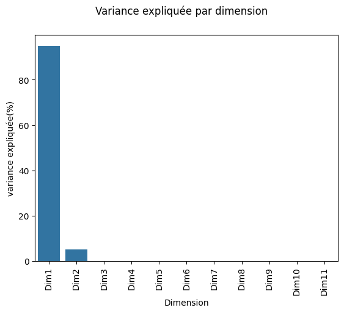

```python
# Supposons que 'comp' est votre DataFrame

g_comp = sns.barplot(x="Dimension", y="% variance expliquée", data=comp)
g_comp.set(ylabel="variance expliquée(%)")
g_comp.figure.suptitle("Variance expliquée par dimension")
plt.xticks(rotation=90)
plt.show()
```

```python
# Calcul du cosinus carré des variables
cos_squared = np.square(pca.components_)

# Création d'un dataframe pandas avec le cosinus carré des variables
df_cos_squared = pd.DataFrame(cos_squared, columns=['PC{}'.format(i+1) for i in range(X.shape[1])])
df_cos_squared.index = data1.columns[:-1]
```

```python
# Contribution à la formation de l'axe
# Obtenir les composantes principales
components = pca.components_

n_components = X.shape[1]
feature_names=data1.columns[0:11]
# Calculer la contribution des variables à la formation des axes
loadings = pca.components_.T
eigenvalues = pca.explained_variance_
variable_contributions = (loadings**2) * eigenvalues

# Créer un DataFrame pour faciliter l'affichage des résultats
column_names = [f'PC{i+1}_contrib' for i in range(n_components)]
variable_contrib_df = pd.DataFrame(variable_contributions, columns=column_names, index=feature_names)
```

#### contribution des variables à la formation des résultats.

```python
# Calculer la contribution des variables à la formation des axes
loadings = pca.components_.T
eigenvalues = pca.explained_variance_
variable_contributions = (loadings**2) * eigenvalues

# Convertir les contributions en pourcentage
variable_contrib_percent = variable_contributions / eigenvalues * 100

# Créer un DataFrame pour faciliter l'affichage des résultats
column_names = [f'PC{i+1}_contrib' for i in range(n_components)]
variable_contrib_df = pd.DataFrame(variable_contrib_percent, columns=column_names, index=feature_names)

print(variable_contrib_df)
```

```
                       PC1_contrib   PC2_contrib  PC3_contrib  PC4_contrib  \
fixed acidity         4.415502e-03  5.972765e-02    97.278656     0.361136
volatile acidity      2.343770e-05  5.938557e-04     0.077448     0.132904
citric acid           7.313623e-07  8.677627e-04     0.631335     0.181715
residual sugar        9.210930e-04  1.480693e-03     0.886809     2.488974
chlorides             2.779407e-07  8.908674e-06     0.000710     0.001506
free sulfur dioxide   5.229664e+00  9.466812e+01     0.073347     0.026706
total sulfur dioxide  9.475931e+01  5.224229e+00     0.000029     0.012945
density               2.627457e-09  1.467426e-07     0.000058     0.000041
pH                    4.392455e-06  1.182590e-03     0.394132     0.016678
sulphates             2.587790e-10  1.887423e-04     0.033256     0.058543
alcohol               5.663236e-03  4.359691e-02     0.624220    96.718852

                      PC5_contrib  PC6_contrib  PC7_contrib  PC8_contrib  \
fixed acidity            1.012124     0.773810     0.011523     0.493444
volatile acidity         0.280664    56.810819     6.659444    19.843750
citric acid              0.052872    31.319987     1.761049    15.418201
residual sugar          96.370140     0.194161     0.001059     0.000108
chlorides                0.004031     0.000270     0.041638     0.098984
free sulfur dioxide      0.001034     0.000129     0.000133     0.000701
total sulfur dioxide     0.003212     0.000040     0.000004     0.000204
density                  0.000125     0.000007     0.000625     0.000909
pH                       0.048265     1.205289     2.826258    63.552314
sulphates                0.035604     9.335668    88.688001     0.575161
alcohol                  2.191929     0.359820     0.010266     0.016224

                      PC9_contrib  PC10_contrib  PC11_contrib
fixed acidity            0.005090  1.704466e-06  7.154144e-05
volatile acidity        16.136769  5.756131e-02  2.373741e-05
citric acid             50.614274  1.969474e-02  3.624893e-06
residual sugar           0.053192  3.067059e-03  8.961681e-05
chlorides                0.005748  9.984123e+01  5.878085e-03
free sulfur dioxide      0.000163  2.617332e-07  6.495730e-09
total sulfur dioxide     0.000030  3.757105e-09  1.044993e-09
density                  0.000756  5.903706e-03  9.999157e+01
pH                      31.924107  2.973867e-02  2.032115e-03
sulphates                1.232847  4.048674e-02  2.435387e-04
alcohol                  0.027025  2.319898e-03  8.298132e-05
```

#### Contribution des individus à la formations des axes.

```python
# Calculer la contribution des individus à la formation des axes
eigenvalues = pca.explained_variance_
contributions = (X_pca**2) / (X_pca.shape[0] * eigenvalues)

# Convertir les contributions en pourcentage
contrib_percent = contributions * 100

# Créer un DataFrame pour faciliter l'affichage des résultats
column_names = [f'PC{i+1}_contrib' for i in range(n_components)]
contrib_df = pd.DataFrame(contrib_percent, columns=column_names)

contrib_df.head()
```

|  | PC1_contrib | PC2_contrib | PC3_contrib | PC4_contrib | PC5_contrib | PC6_contrib | PC7_contrib | PC8_contrib | PC9_contrib | PC10_contrib | PC11_contrib |
| --- | --- | --- | --- | --- | --- | --- | --- | --- | --- | --- | --- |
| 0 | 0.010006 | 0.004558 | 0.022808 | 0.085632 | 0.001984 | 0.067420 | 0.005009 | 0.115072 | 0.007235 | 0.002768 | 0.038029 |
| 1 | 0.033655 | 0.022615 | 0.000845 | 0.016803 | 0.023043 | 0.185054 | 0.070443 | 0.153088 | 0.078631 | 0.008065 | 0.002954 |
| 2 | 0.004036 | 0.008469 | 0.005311 | 0.018469 | 0.001453 | 0.086799 | 0.030639 | 0.025901 | 0.053938 | 0.005528 | 0.003978 |
| 3 | 0.012969 | 0.005531 | 0.198058 | 0.007005 | 0.098665 | 0.015439 | 0.096276 | 0.071032 | 0.003366 | 0.008067 | 0.034511 |
| 4 | 0.010006 | 0.004558 | 0.022808 | 0.085632 | 0.001984 | 0.067420 | 0.005009 | 0.115072 | 0.007235 | 0.002768 | 0.038029 |

#### interprétion du cercle

on peut voir que :

- "total sulfur dioxide" est bien corrélée avec la première composante.
- "free sulfur dioxide" est également corrélée mais dans une direction différente. La plupart des autres variables sont proches du centre, indiquant une faible corrélation avec les axes principaux.

[figure not shown]

```python
# Créer le cercle de corrélation
coeff = np.transpose(pca.components_[0:2, :])
n = coeff.shape[0]
xs = np.array([1, 0])
ys = np.array([0, 1])

# Créer la figure
plt.figure(figsize=(12, 12))

# Placer les vecteurs des variables
for i in range(n):
    plt.arrow(0, 0, coeff[i, 0], coeff[i, 1], color='k', alpha=0.9, head_width=0.02)
    plt.text(coeff[i, 0] * 1.15, coeff[i, 1] * 1.15, feature_names[i], color='k', ha='center', va='center')

# Placer le cercle unitaire
circle = plt.Circle((0, 0), 1, color='gray', fill=False, linestyle='--')
plt.gca().add_artist(circle)

# Ajuster les limites et les axes
plt.xlim(-1, 1)
plt.ylim(-1, 1)
# plt.zlim(-1, 1)
plt.axhline(0, color='gray', linewidth=1)
plt.axvline(0, color='gray', linewidth=1)
plt.xlabel('PC1')
plt.ylabel('PC2')
plt.ylabel('PC3')
plt.title('Cercle de corrélation ACP vin rouge')

# Afficher la figure
plt.show()
```